# DV7week

`-` imports

```python
import numpy as np
import pandas as pd
import matplotlib.pyplot as plt
from plotnine import *
```

```python
df=pd.read_csv('https://raw.githubusercontent.com/PacktPublishing/Pandas-Cookbook/master/data/movie.csv')
df
```

|  | color | director_name | num_critic_for_reviews | duration | director_facebook_likes | actor_3_facebook_likes | actor_2_name | actor_1_facebook_likes | gross | genres | ... | num_user_for_reviews | language | country | content_rating | budget | title_year | actor_2_facebook_likes | imdb_score | aspect_ratio | movie_facebook_likes |
| --- | --- | --- | --- | --- | --- | --- | --- | --- | --- | --- | --- | --- | --- | --- | --- | --- | --- | --- | --- | --- | --- |
| 0 | Color | James Cameron | 723.0 | 178.0 | 0.0 | 855.0 | Joel David Moore | 1000.0 | 760505847.0 | Action\|Adventure\|Fantasy\|Sci-Fi | ... | 3054.0 | English | USA | PG-13 | 237000000.0 | 2009.0 | 936.0 | 7.9 | 1.78 | 33000 |
| 1 | Color | Gore Verbinski | 302.0 | 169.0 | 563.0 | 1000.0 | Orlando Bloom | 40000.0 | 309404152.0 | Action\|Adventure\|Fantasy | ... | 1238.0 | English | USA | PG-13 | 300000000.0 | 2007.0 | 5000.0 | 7.1 | 2.35 | 0 |
| 2 | Color | Sam Mendes | 602.0 | 148.0 | 0.0 | 161.0 | Rory Kinnear | 11000.0 | 200074175.0 | Action\|Adventure\|Thriller | ... | 994.0 | English | UK | PG-13 | 245000000.0 | 2015.0 | 393.0 | 6.8 | 2.35 | 85000 |
| 3 | Color | Christopher Nolan | 813.0 | 164.0 | 22000.0 | 23000.0 | Christian Bale | 27000.0 | 448130642.0 | Action\|Thriller | ... | 2701.0 | English | USA | PG-13 | 250000000.0 | 2012.0 | 23000.0 | 8.5 | 2.35 | 164000 |
| 4 | NaN | Doug Walker | NaN | NaN | 131.0 | NaN | Rob Walker | 131.0 | NaN | Documentary | ... | NaN | NaN | NaN | NaN | NaN | NaN | 12.0 | 7.1 | NaN | 0 |
| ... | ... | ... | ... | ... | ... | ... | ... | ... | ... | ... | ... | ... | ... | ... | ... | ... | ... | ... | ... | ... | ... |
| 4911 | Color | Scott Smith | 1.0 | 87.0 | 2.0 | 318.0 | Daphne Zuniga | 637.0 | NaN | Comedy\|Drama | ... | 6.0 | English | Canada | NaN | NaN | 2013.0 | 470.0 | 7.7 | NaN | 84 |
| 4912 | Color | NaN | 43.0 | 43.0 | NaN | 319.0 | Valorie Curry | 841.0 | NaN | Crime\|Drama\|Mystery\|Thriller | ... | 359.0 | English | USA | TV-14 | NaN | NaN | 593.0 | 7.5 | 16.00 | 32000 |
| 4913 | Color | Benjamin Roberds | 13.0 | 76.0 | 0.0 | 0.0 | Maxwell Moody | 0.0 | NaN | Drama\|Horror\|Thriller | ... | 3.0 | English | USA | NaN | 1400.0 | 2013.0 | 0.0 | 6.3 | NaN | 16 |
| 4914 | Color | Daniel Hsia | 14.0 | 100.0 | 0.0 | 489.0 | Daniel Henney | 946.0 | 10443.0 | Comedy\|Drama\|Romance | ... | 9.0 | English | USA | PG-13 | NaN | 2012.0 | 719.0 | 6.3 | 2.35 | 660 |
| 4915 | Color | Jon Gunn | 43.0 | 90.0 | 16.0 | 16.0 | Brian Herzlinger | 86.0 | 85222.0 | Documentary | ... | 84.0 | English | USA | PG | 1100.0 | 2004.0 | 23.0 | 6.6 | 1.85 | 456 |

4916 rows × 28 columns

```python
df.columns , df.keys()
```

```
(Index(['color', 'director_name', 'num_critic_for_reviews', 'duration',
        'director_facebook_likes', 'actor_3_facebook_likes', 'actor_2_name',
        'actor_1_facebook_likes', 'gross', 'genres', 'actor_1_name',
        'movie_title', 'num_voted_users', 'cast_total_facebook_likes',
        'actor_3_name', 'facenumber_in_poster', 'plot_keywords',
        'movie_imdb_link', 'num_user_for_reviews', 'language', 'country',
        'content_rating', 'budget', 'title_year', 'actor_2_facebook_likes',
        'imdb_score', 'aspect_ratio', 'movie_facebook_likes'],
       dtype='object'),
 Index(['color', 'director_name', 'num_critic_for_reviews', 'duration',
        'director_facebook_likes', 'actor_3_facebook_likes', 'actor_2_name',
        'actor_1_facebook_likes', 'gross', 'genres', 'actor_1_name',
        'movie_title', 'num_voted_users', 'cast_total_facebook_likes',
        'actor_3_name', 'facenumber_in_poster', 'plot_keywords',
        'movie_imdb_link', 'num_user_for_reviews', 'language', 'country',
        'content_rating', 'budget', 'title_year', 'actor_2_facebook_likes',
        'imdb_score', 'aspect_ratio', 'movie_facebook_likes'],
       dtype='object'))
```

```python
#color라는 칼럼 뽑고싶다
df.loc[:,'color']
```

```
0       Color
1       Color
2       Color
3       Color
4         NaN
        ...
4911    Color
4912    Color
4913    Color
4914    Color
4915    Color
Name: color, Length: 4916, dtype: object
```

```python
df.loc[:,['color']] #시리즈를 데이터 프레임으로 보고싶다.
```

|  | color |
| --- | --- |
| 0 | Color |
| 1 | Color |
| 2 | Color |
| 3 | Color |
| 4 | NaN |
| ... | ... |
| 4911 | Color |
| 4912 | Color |
| 4913 | Color |
| 4914 | Color |
| 4915 | Color |

4916 rows × 1 columns

```python
df.loc[:,['color','director_name']]
```

|  | color | director_name |
| --- | --- | --- |
| 0 | Color | James Cameron |
| 1 | Color | Gore Verbinski |
| 2 | Color | Sam Mendes |
| 3 | Color | Christopher Nolan |
| 4 | NaN | Doug Walker |
| ... | ... | ... |
| 4911 | Color | Scott Smith |
| 4912 | Color | NaN |
| 4913 | Color | Benjamin Roberds |
| 4914 | Color | Daniel Hsia |
| 4915 | Color | Jon Gunn |

4916 rows × 2 columns

```python
df.loc[:,'color':'num_critic_for_reviews']
```

|  | color | director_name | num_critic_for_reviews |
| --- | --- | --- | --- |
| 0 | Color | James Cameron | 723.0 |
| 1 | Color | Gore Verbinski | 302.0 |
| 2 | Color | Sam Mendes | 602.0 |
| 3 | Color | Christopher Nolan | 813.0 |
| 4 | NaN | Doug Walker | NaN |
| ... | ... | ... | ... |
| 4911 | Color | Scott Smith | 1.0 |
| 4912 | Color | NaN | 43.0 |
| 4913 | Color | Benjamin Roberds | 13.0 |
| 4914 | Color | Daniel Hsia | 14.0 |
| 4915 | Color | Jon Gunn | 43.0 |

4916 rows × 3 columns

```python
#여러개를 슬라이싱하고 나머지 좀 떨어진 친구를 같이 인덱싱하고싶다.
df.loc[:,['color':'title_year','aspect_ratio]]
```

```
  Input In [14]
    df.loc[:,['color':'title_year','aspect_ratio]]
                     ^
SyntaxError: invalid syntax
```

안됨

```python
#넘파이 느낌으로 구현해보장
df.loc[:,['color':'title_year','aspect_ratio]]
```

```
  Input In [16]
    df.loc[:,['color':'title_year','aspect_ratio]]
                     ^
SyntaxError: invalid syntax
```

안됨

```python
pd.Series(df.columns)
```

```
0                         color
1                 director_name
2        num_critic_for_reviews
3                      duration
4       director_facebook_likes
5        actor_3_facebook_likes
6                  actor_2_name
7        actor_1_facebook_likes
8                         gross
9                        genres
10                 actor_1_name
11                  movie_title
12              num_voted_users
13    cast_total_facebook_likes
14                 actor_3_name
15         facenumber_in_poster
16                plot_keywords
17              movie_imdb_link
18         num_user_for_reviews
19                     language
20                      country
21               content_rating
22                       budget
23                   title_year
24       actor_2_facebook_likes
25                   imdb_score
26                 aspect_ratio
27         movie_facebook_likes
dtype: object
```

```python
color = 0
title_year = 24
aspect_ratio = 26
```

```python
list(range(24)) + [26]
```

```
[0,
 1,
 2,
 3,
 4,
 5,
 6,
 7,
 8,
 9,
 10,
 11,
 12,
 13,
 14,
 15,
 16,
 17,
 18,
 19,
 20,
 21,
 22,
 23,
 26]
```

```python
df.iloc[:,list(range(24)) + [26]]
```

|  | color | director_name | num_critic_for_reviews | duration | director_facebook_likes | actor_3_facebook_likes | actor_2_name | actor_1_facebook_likes | gross | genres | ... | facenumber_in_poster | plot_keywords | movie_imdb_link | num_user_for_reviews | language | country | content_rating | budget | title_year | aspect_ratio |
| --- | --- | --- | --- | --- | --- | --- | --- | --- | --- | --- | --- | --- | --- | --- | --- | --- | --- | --- | --- | --- | --- |
| 0 | Color | James Cameron | 723.0 | 178.0 | 0.0 | 855.0 | Joel David Moore | 1000.0 | 760505847.0 | Action\|Adventure\|Fantasy\|Sci-Fi | ... | 0.0 | avatar\|future\|marine\|native\|paraplegic | http://www.imdb.com/title/tt0499549/?ref_=fn_t... | 3054.0 | English | USA | PG-13 | 237000000.0 | 2009.0 | 1.78 |
| 1 | Color | Gore Verbinski | 302.0 | 169.0 | 563.0 | 1000.0 | Orlando Bloom | 40000.0 | 309404152.0 | Action\|Adventure\|Fantasy | ... | 0.0 | goddess\|marriage ceremony\|marriage proposal\|pi... | http://www.imdb.com/title/tt0449088/?ref_=fn_t... | 1238.0 | English | USA | PG-13 | 300000000.0 | 2007.0 | 2.35 |
| 2 | Color | Sam Mendes | 602.0 | 148.0 | 0.0 | 161.0 | Rory Kinnear | 11000.0 | 200074175.0 | Action\|Adventure\|Thriller | ... | 1.0 | bomb\|espionage\|sequel\|spy\|terrorist | http://www.imdb.com/title/tt2379713/?ref_=fn_t... | 994.0 | English | UK | PG-13 | 245000000.0 | 2015.0 | 2.35 |
| 3 | Color | Christopher Nolan | 813.0 | 164.0 | 22000.0 | 23000.0 | Christian Bale | 27000.0 | 448130642.0 | Action\|Thriller | ... | 0.0 | deception\|imprisonment\|lawlessness\|police offi... | http://www.imdb.com/title/tt1345836/?ref_=fn_t... | 2701.0 | English | USA | PG-13 | 250000000.0 | 2012.0 | 2.35 |
| 4 | NaN | Doug Walker | NaN | NaN | 131.0 | NaN | Rob Walker | 131.0 | NaN | Documentary | ... | 0.0 | NaN | http://www.imdb.com/title/tt5289954/?ref_=fn_t... | NaN | NaN | NaN | NaN | NaN | NaN | NaN |
| ... | ... | ... | ... | ... | ... | ... | ... | ... | ... | ... | ... | ... | ... | ... | ... | ... | ... | ... | ... | ... | ... |
| 4911 | Color | Scott Smith | 1.0 | 87.0 | 2.0 | 318.0 | Daphne Zuniga | 637.0 | NaN | Comedy\|Drama | ... | 2.0 | fraud\|postal worker\|prison\|theft\|trial | http://www.imdb.com/title/tt3000844/?ref_=fn_t... | 6.0 | English | Canada | NaN | NaN | 2013.0 | NaN |
| 4912 | Color | NaN | 43.0 | 43.0 | NaN | 319.0 | Valorie Curry | 841.0 | NaN | Crime\|Drama\|Mystery\|Thriller | ... | 1.0 | cult\|fbi\|hideout\|prison escape\|serial killer | http://www.imdb.com/title/tt2071645/?ref_=fn_t... | 359.0 | English | USA | TV-14 | NaN | NaN | 16.00 |
| 4913 | Color | Benjamin Roberds | 13.0 | 76.0 | 0.0 | 0.0 | Maxwell Moody | 0.0 | NaN | Drama\|Horror\|Thriller | ... | 0.0 | NaN | http://www.imdb.com/title/tt2107644/?ref_=fn_t... | 3.0 | English | USA | NaN | 1400.0 | 2013.0 | NaN |
| 4914 | Color | Daniel Hsia | 14.0 | 100.0 | 0.0 | 489.0 | Daniel Henney | 946.0 | 10443.0 | Comedy\|Drama\|Romance | ... | 5.0 | NaN | http://www.imdb.com/title/tt2070597/?ref_=fn_t... | 9.0 | English | USA | PG-13 | NaN | 2012.0 | 2.35 |
| 4915 | Color | Jon Gunn | 43.0 | 90.0 | 16.0 | 16.0 | Brian Herzlinger | 86.0 | 85222.0 | Documentary | ... | 0.0 | actress name in title\|crush\|date\|four word tit... | http://www.imdb.com/title/tt0378407/?ref_=fn_t... | 84.0 | English | USA | PG | 1100.0 | 2004.0 | 1.85 |

4916 rows × 25 columns

```python
df.columns
```

```
Index(['color', 'director_name', 'num_critic_for_reviews', 'duration',
       'director_facebook_likes', 'actor_3_facebook_likes', 'actor_2_name',
       'actor_1_facebook_likes', 'gross', 'genres', 'actor_1_name',
       'movie_title', 'num_voted_users', 'cast_total_facebook_likes',
       'actor_3_name', 'facenumber_in_poster', 'plot_keywords',
       'movie_imdb_link', 'num_user_for_reviews', 'language', 'country',
       'content_rating', 'budget', 'title_year', 'actor_2_facebook_likes',
       'imdb_score', 'aspect_ratio', 'movie_facebook_likes'],
      dtype='object')
```

# 10월 17일강의

### actor라는 단어가 포함된 열을 선택하고싶다

```python
list(map(lambda x: 'actor' in x, df.columns))
```

```
[False,
 False,
 False,
 False,
 False,
 True,
 True,
 True,
 False,
 False,
 True,
 False,
 False,
 False,
 True,
 False,
 False,
 False,
 False,
 False,
 False,
 False,
 False,
 False,
 True,
 False,
 False,
 False]
```

#### 방법 1. iloc/map,lambda

```python
df.iloc[:,list(map(lambda x: 'actor' in x, df.columns))]
```

|  | actor_3_facebook_likes | actor_2_name | actor_1_facebook_likes | actor_1_name | actor_3_name | actor_2_facebook_likes |
| --- | --- | --- | --- | --- | --- | --- |
| 0 | 855.0 | Joel David Moore | 1000.0 | CCH Pounder | Wes Studi | 936.0 |
| 1 | 1000.0 | Orlando Bloom | 40000.0 | Johnny Depp | Jack Davenport | 5000.0 |
| 2 | 161.0 | Rory Kinnear | 11000.0 | Christoph Waltz | Stephanie Sigman | 393.0 |
| 3 | 23000.0 | Christian Bale | 27000.0 | Tom Hardy | Joseph Gordon-Levitt | 23000.0 |
| 4 | NaN | Rob Walker | 131.0 | Doug Walker | NaN | 12.0 |
| ... | ... | ... | ... | ... | ... | ... |
| 4911 | 318.0 | Daphne Zuniga | 637.0 | Eric Mabius | Crystal Lowe | 470.0 |
| 4912 | 319.0 | Valorie Curry | 841.0 | Natalie Zea | Sam Underwood | 593.0 |
| 4913 | 0.0 | Maxwell Moody | 0.0 | Eva Boehnke | David Chandler | 0.0 |
| 4914 | 489.0 | Daniel Henney | 946.0 | Alan Ruck | Eliza Coupe | 719.0 |
| 4915 | 16.0 | Brian Herzlinger | 86.0 | John August | Jon Gunn | 23.0 |

4916 rows × 6 columns

덜덜하다..

`-`꼭 list가 아니어도 됨 map으로 받을 수 있음

#### 방법2

```python
df.iloc[:,map(lambda x: 'actor' in x, df.columns)]
```

|  | actor_3_facebook_likes | actor_2_name | actor_1_facebook_likes | actor_1_name | actor_3_name | actor_2_facebook_likes |
| --- | --- | --- | --- | --- | --- | --- |
| 0 | 855.0 | Joel David Moore | 1000.0 | CCH Pounder | Wes Studi | 936.0 |
| 1 | 1000.0 | Orlando Bloom | 40000.0 | Johnny Depp | Jack Davenport | 5000.0 |
| 2 | 161.0 | Rory Kinnear | 11000.0 | Christoph Waltz | Stephanie Sigman | 393.0 |
| 3 | 23000.0 | Christian Bale | 27000.0 | Tom Hardy | Joseph Gordon-Levitt | 23000.0 |
| 4 | NaN | Rob Walker | 131.0 | Doug Walker | NaN | 12.0 |
| ... | ... | ... | ... | ... | ... | ... |
| 4911 | 318.0 | Daphne Zuniga | 637.0 | Eric Mabius | Crystal Lowe | 470.0 |
| 4912 | 319.0 | Valorie Curry | 841.0 | Natalie Zea | Sam Underwood | 593.0 |
| 4913 | 0.0 | Maxwell Moody | 0.0 | Eva Boehnke | David Chandler | 0.0 |
| 4914 | 489.0 | Daniel Henney | 946.0 | Alan Ruck | Eliza Coupe | 719.0 |
| 4915 | 16.0 | Brian Herzlinger | 86.0 | John August | Jon Gunn | 23.0 |

4916 rows × 6 columns

#### 방법3 loc/list(map,lambda)

```python
df.loc[:,list(map(lambda x: 'actor' in x, df.columns))]
```

|  | actor_3_facebook_likes | actor_2_name | actor_1_facebook_likes | actor_1_name | actor_3_name | actor_2_facebook_likes |
| --- | --- | --- | --- | --- | --- | --- |
| 0 | 855.0 | Joel David Moore | 1000.0 | CCH Pounder | Wes Studi | 936.0 |
| 1 | 1000.0 | Orlando Bloom | 40000.0 | Johnny Depp | Jack Davenport | 5000.0 |
| 2 | 161.0 | Rory Kinnear | 11000.0 | Christoph Waltz | Stephanie Sigman | 393.0 |
| 3 | 23000.0 | Christian Bale | 27000.0 | Tom Hardy | Joseph Gordon-Levitt | 23000.0 |
| 4 | NaN | Rob Walker | 131.0 | Doug Walker | NaN | 12.0 |
| ... | ... | ... | ... | ... | ... | ... |
| 4911 | 318.0 | Daphne Zuniga | 637.0 | Eric Mabius | Crystal Lowe | 470.0 |
| 4912 | 319.0 | Valorie Curry | 841.0 | Natalie Zea | Sam Underwood | 593.0 |
| 4913 | 0.0 | Maxwell Moody | 0.0 | Eva Boehnke | David Chandler | 0.0 |
| 4914 | 489.0 | Daniel Henney | 946.0 | Alan Ruck | Eliza Coupe | 719.0 |
| 4915 | 16.0 | Brian Herzlinger | 86.0 | John August | Jon Gunn | 23.0 |

4916 rows × 6 columns

#### 방법 4 loc/map,lambda

```python
df.loc[:,map(lambda x: 'actor' in x, df.columns)]
```

|  | actor_3_facebook_likes | actor_2_name | actor_1_facebook_likes | actor_1_name | actor_3_name | actor_2_facebook_likes |
| --- | --- | --- | --- | --- | --- | --- |
| 0 | 855.0 | Joel David Moore | 1000.0 | CCH Pounder | Wes Studi | 936.0 |
| 1 | 1000.0 | Orlando Bloom | 40000.0 | Johnny Depp | Jack Davenport | 5000.0 |
| 2 | 161.0 | Rory Kinnear | 11000.0 | Christoph Waltz | Stephanie Sigman | 393.0 |
| 3 | 23000.0 | Christian Bale | 27000.0 | Tom Hardy | Joseph Gordon-Levitt | 23000.0 |
| 4 | NaN | Rob Walker | 131.0 | Doug Walker | NaN | 12.0 |
| ... | ... | ... | ... | ... | ... | ... |
| 4911 | 318.0 | Daphne Zuniga | 637.0 | Eric Mabius | Crystal Lowe | 470.0 |
| 4912 | 319.0 | Valorie Curry | 841.0 | Natalie Zea | Sam Underwood | 593.0 |
| 4913 | 0.0 | Maxwell Moody | 0.0 | Eva Boehnke | David Chandler | 0.0 |
| 4914 | 489.0 | Daniel Henney | 946.0 | Alan Ruck | Eliza Coupe | 719.0 |
| 4915 | 16.0 | Brian Herzlinger | 86.0 | John August | Jon Gunn | 23.0 |

4916 rows × 6 columns

### s로 끝나는 열 선택

```python
df.columns
```

```
Index(['color', 'director_name', 'num_critic_for_reviews', 'duration',
       'director_facebook_likes', 'actor_3_facebook_likes', 'actor_2_name',
       'actor_1_facebook_likes', 'gross', 'genres', 'actor_1_name',
       'movie_title', 'num_voted_users', 'cast_total_facebook_likes',
       'actor_3_name', 'facenumber_in_poster', 'plot_keywords',
       'movie_imdb_link', 'num_user_for_reviews', 'language', 'country',
       'content_rating', 'budget', 'title_year', 'actor_2_facebook_likes',
       'imdb_score', 'aspect_ratio', 'movie_facebook_likes'],
      dtype='object')
```

#### 방법1 loc/map,lambda

```python
df.loc[:,map(lambda x: 's'==x[-1], df.columns)]
```

|  | num_critic_for_reviews | director_facebook_likes | actor_3_facebook_likes | actor_1_facebook_likes | gross | genres | num_voted_users | cast_total_facebook_likes | plot_keywords | num_user_for_reviews | actor_2_facebook_likes | movie_facebook_likes |
| --- | --- | --- | --- | --- | --- | --- | --- | --- | --- | --- | --- | --- |
| 0 | 723.0 | 0.0 | 855.0 | 1000.0 | 760505847.0 | Action\|Adventure\|Fantasy\|Sci-Fi | 886204 | 4834 | avatar\|future\|marine\|native\|paraplegic | 3054.0 | 936.0 | 33000 |
| 1 | 302.0 | 563.0 | 1000.0 | 40000.0 | 309404152.0 | Action\|Adventure\|Fantasy | 471220 | 48350 | goddess\|marriage ceremony\|marriage proposal\|pi... | 1238.0 | 5000.0 | 0 |
| 2 | 602.0 | 0.0 | 161.0 | 11000.0 | 200074175.0 | Action\|Adventure\|Thriller | 275868 | 11700 | bomb\|espionage\|sequel\|spy\|terrorist | 994.0 | 393.0 | 85000 |
| 3 | 813.0 | 22000.0 | 23000.0 | 27000.0 | 448130642.0 | Action\|Thriller | 1144337 | 106759 | deception\|imprisonment\|lawlessness\|police offi... | 2701.0 | 23000.0 | 164000 |
| 4 | NaN | 131.0 | NaN | 131.0 | NaN | Documentary | 8 | 143 | NaN | NaN | 12.0 | 0 |
| ... | ... | ... | ... | ... | ... | ... | ... | ... | ... | ... | ... | ... |
| 4911 | 1.0 | 2.0 | 318.0 | 637.0 | NaN | Comedy\|Drama | 629 | 2283 | fraud\|postal worker\|prison\|theft\|trial | 6.0 | 470.0 | 84 |
| 4912 | 43.0 | NaN | 319.0 | 841.0 | NaN | Crime\|Drama\|Mystery\|Thriller | 73839 | 1753 | cult\|fbi\|hideout\|prison escape\|serial killer | 359.0 | 593.0 | 32000 |
| 4913 | 13.0 | 0.0 | 0.0 | 0.0 | NaN | Drama\|Horror\|Thriller | 38 | 0 | NaN | 3.0 | 0.0 | 16 |
| 4914 | 14.0 | 0.0 | 489.0 | 946.0 | 10443.0 | Comedy\|Drama\|Romance | 1255 | 2386 | NaN | 9.0 | 719.0 | 660 |
| 4915 | 43.0 | 16.0 | 16.0 | 86.0 | 85222.0 | Documentary | 4285 | 163 | actress name in title\|crush\|date\|four word tit... | 84.0 | 23.0 | 456 |

4916 rows × 12 columns

#### 방법2 iloc/map,lambda

```python
df.iloc[:,map(lambda x: 's'== x[-1], df.columns)]
```

|  | num_critic_for_reviews | director_facebook_likes | actor_3_facebook_likes | actor_1_facebook_likes | gross | genres | num_voted_users | cast_total_facebook_likes | plot_keywords | num_user_for_reviews | actor_2_facebook_likes | movie_facebook_likes |
| --- | --- | --- | --- | --- | --- | --- | --- | --- | --- | --- | --- | --- |
| 0 | 723.0 | 0.0 | 855.0 | 1000.0 | 760505847.0 | Action\|Adventure\|Fantasy\|Sci-Fi | 886204 | 4834 | avatar\|future\|marine\|native\|paraplegic | 3054.0 | 936.0 | 33000 |
| 1 | 302.0 | 563.0 | 1000.0 | 40000.0 | 309404152.0 | Action\|Adventure\|Fantasy | 471220 | 48350 | goddess\|marriage ceremony\|marriage proposal\|pi... | 1238.0 | 5000.0 | 0 |
| 2 | 602.0 | 0.0 | 161.0 | 11000.0 | 200074175.0 | Action\|Adventure\|Thriller | 275868 | 11700 | bomb\|espionage\|sequel\|spy\|terrorist | 994.0 | 393.0 | 85000 |
| 3 | 813.0 | 22000.0 | 23000.0 | 27000.0 | 448130642.0 | Action\|Thriller | 1144337 | 106759 | deception\|imprisonment\|lawlessness\|police offi... | 2701.0 | 23000.0 | 164000 |
| 4 | NaN | 131.0 | NaN | 131.0 | NaN | Documentary | 8 | 143 | NaN | NaN | 12.0 | 0 |
| ... | ... | ... | ... | ... | ... | ... | ... | ... | ... | ... | ... | ... |
| 4911 | 1.0 | 2.0 | 318.0 | 637.0 | NaN | Comedy\|Drama | 629 | 2283 | fraud\|postal worker\|prison\|theft\|trial | 6.0 | 470.0 | 84 |
| 4912 | 43.0 | NaN | 319.0 | 841.0 | NaN | Crime\|Drama\|Mystery\|Thriller | 73839 | 1753 | cult\|fbi\|hideout\|prison escape\|serial killer | 359.0 | 593.0 | 32000 |
| 4913 | 13.0 | 0.0 | 0.0 | 0.0 | NaN | Drama\|Horror\|Thriller | 38 | 0 | NaN | 3.0 | 0.0 | 16 |
| 4914 | 14.0 | 0.0 | 489.0 | 946.0 | 10443.0 | Comedy\|Drama\|Romance | 1255 | 2386 | NaN | 9.0 | 719.0 | 660 |
| 4915 | 43.0 | 16.0 | 16.0 | 86.0 | 85222.0 | Documentary | 4285 | 163 | actress name in title\|crush\|date\|four word tit... | 84.0 | 23.0 | 456 |

4916 rows × 12 columns

### c 또는 d로 시작하는 열을 선택해보자

#### 방법1 iloc/map,lambda

```python
df.iloc[:,map(lambda x: 'c' == x[0] or 'd' == x[0],df.columns)]
```

|  | color | director_name | duration | director_facebook_likes | cast_total_facebook_likes | country | content_rating |
| --- | --- | --- | --- | --- | --- | --- | --- |
| 0 | Color | James Cameron | 178.0 | 0.0 | 4834 | USA | PG-13 |
| 1 | Color | Gore Verbinski | 169.0 | 563.0 | 48350 | USA | PG-13 |
| 2 | Color | Sam Mendes | 148.0 | 0.0 | 11700 | UK | PG-13 |
| 3 | Color | Christopher Nolan | 164.0 | 22000.0 | 106759 | USA | PG-13 |
| 4 | NaN | Doug Walker | NaN | 131.0 | 143 | NaN | NaN |
| ... | ... | ... | ... | ... | ... | ... | ... |
| 4911 | Color | Scott Smith | 87.0 | 2.0 | 2283 | Canada | NaN |
| 4912 | Color | NaN | 43.0 | NaN | 1753 | USA | TV-14 |
| 4913 | Color | Benjamin Roberds | 76.0 | 0.0 | 0 | USA | NaN |
| 4914 | Color | Daniel Hsia | 100.0 | 0.0 | 2386 | USA | PG-13 |
| 4915 | Color | Jon Gunn | 90.0 | 16.0 | 163 | USA | PG |

4916 rows × 7 columns

#### 방법2 loc/map,lambda

```python
df.loc[:, map(lambda x: 'c' == x[0] or 'd' == x[0], df.columns)]
```

|  | color | director_name | duration | director_facebook_likes | cast_total_facebook_likes | country | content_rating |
| --- | --- | --- | --- | --- | --- | --- | --- |
| 0 | Color | James Cameron | 178.0 | 0.0 | 4834 | USA | PG-13 |
| 1 | Color | Gore Verbinski | 169.0 | 563.0 | 48350 | USA | PG-13 |
| 2 | Color | Sam Mendes | 148.0 | 0.0 | 11700 | UK | PG-13 |
| 3 | Color | Christopher Nolan | 164.0 | 22000.0 | 106759 | USA | PG-13 |
| 4 | NaN | Doug Walker | NaN | 131.0 | 143 | NaN | NaN |
| ... | ... | ... | ... | ... | ... | ... | ... |
| 4911 | Color | Scott Smith | 87.0 | 2.0 | 2283 | Canada | NaN |
| 4912 | Color | NaN | 43.0 | NaN | 1753 | USA | TV-14 |
| 4913 | Color | Benjamin Roberds | 76.0 | 0.0 | 0 | USA | NaN |
| 4914 | Color | Daniel Hsia | 100.0 | 0.0 | 2386 | USA | PG-13 |
| 4915 | Color | Jon Gunn | 90.0 | 16.0 | 163 | USA | PG |

4916 rows × 7 columns

# df:새로운 열의 할당 1단계

```python
df = pd.DataFrame({'a':[1,2,3],'b':[2,3,4]})
df
```

|  | a | b |
| --- | --- | --- |
| 0 | 1 | 2 |
| 1 | 2 | 3 |
| 2 | 3 | 4 |

## 방법 1: concatenate

```python
_df = pd.DataFrame({'c':[3,4,5]})
_df
```

|  | c |
| --- | --- |
| 0 | 3 |
| 1 | 4 |
| 2 | 5 |

```python
pd.concat([df,_df],axis=1) # 지양하는 것이 좋음
```

|  | a | b | c |
| --- | --- | --- | --- |
| 0 | 1 | 2 | 3 |
| 1 | 2 | 3 | 4 |
| 2 | 3 | 4 | 5 |

## 방법2 : 4가지 컨셉에 따른 할당

### 컨셉1: 불가능

```python
df
```

|  | a | b |
| --- | --- | --- |
| 0 | 1 | 2 |
| 1 | 2 | 3 |
| 2 | 3 | 4 |

```python
df.c=[3,4,5] #이런건 되지 않는다
```

```python
df.c = pd.Series([1,2,3])
df #안됨
```

|  | a | b |
| --- | --- | --- |
| 0 | 1 | 2 |
| 1 | 2 | 3 |
| 2 | 3 | 4 |

### 컨셉2:가능

#### 예시1

```python
dct = {'a':[1,2,3],'b':[2,3,4]}
dct
```

```
{'a': [1, 2, 3], 'b': [2, 3, 4]}
```

```python
dct['c'] = [3,4,5]
```

```python
dct
```

```
{'a': [1, 2, 3], 'b': [2, 3, 4], 'c': [3, 4, 5]}
```

```python
df = pd.DataFrame(dct)
df
```

|  | a | b | c |
| --- | --- | --- | --- |
| 0 | 1 | 2 | 3 |
| 1 | 2 | 3 | 4 |
| 2 | 3 | 4 | 5 |

#### 예시2

```python
df= pd.DataFrame({'a':[1,2,3],'b':[2,3,4]})
df
```

|  | a | b |
| --- | --- | --- |
| 0 | 1 | 2 |
| 1 | 2 | 3 |
| 2 | 3 | 4 |

```python
df['c'] = [3,4,5]
```

```python
df
```

|  | a | b | c |
| --- | --- | --- | --- |
| 0 | 1 | 2 | 3 |
| 1 | 2 | 3 | 4 |
| 2 | 3 | 4 | 5 |

#### 예시3 뇌절

```python
df= pd.DataFrame({'a':[1,2,3],'b':[2,3,4]})
df
```

|  | a | b |
| --- | --- | --- |
| 0 | 1 | 2 |
| 1 | 2 | 3 |
| 2 | 3 | 4 |

```python
df[['c','d']] =np.array([[3,4,5],[4,5,6]]).T
df
```

|  | a | b | c | d |
| --- | --- | --- | --- | --- |
| 0 | 1 | 2 | 3 | 4 |
| 1 | 2 | 3 | 4 | 5 |
| 2 | 3 | 4 | 5 | 6 |

```python
#언패킹 연산자
df['c'],df['d'] = [3,4,5],[4,5,6]
df
```

|  | a | b | c | d |
| --- | --- | --- | --- | --- |
| 0 | 1 | 2 | 3 | 4 |
| 1 | 2 | 3 | 4 | 5 |
| 2 | 3 | 4 | 5 | 6 |

### 컨셉3:불가능

```python
df.iloc[:2] = [3,4,5]
df
```

[output not shown]

### 컨셉4:가능

#### 예시1

```python
df= pd.DataFrame({'a':[1,2,3],'b':[2,3,4]})
df
```

|  | a | b |
| --- | --- | --- |
| 0 | 1 | 2 |
| 1 | 2 | 3 |
| 2 | 3 | 4 |

```python
df.loc[:,'c'] = [3,4,5]
df
```

|  | a | b | c |
| --- | --- | --- | --- |
| 0 | 1 | 2 | 3 |
| 1 | 2 | 3 | 4 |
| 2 | 3 | 4 | 5 |

#### 예시2

```python
df= pd.DataFrame({'a':[1,2,3],'b':[2,3,4]})
df
```

|  | a | b |
| --- | --- | --- |
| 0 | 1 | 2 |
| 1 | 2 | 3 |
| 2 | 3 | 4 |

```python
df.loc[:,['c','d']] = np.array([[3,4,5],[4,5,6]]).T
df
```

|  | a | b | c | d |
| --- | --- | --- | --- | --- |
| 0 | 1 | 2 | 3 | 4 |
| 1 | 2 | 3 | 4 | 5 |
| 2 | 3 | 4 | 5 | 6 |

#### 예시3

```python
df= pd.DataFrame({'a':[1,2,3],'b':[2,3,4]})
df
```

|  | a | b |
| --- | --- | --- |
| 0 | 1 | 2 |
| 1 | 2 | 3 |
| 2 | 3 | 4 |

```python
df.loc[:,'c'], df.loc[:,'d'] = [3,4,5],[4,5,6]
df
```

|  | a | b | c | d |
| --- | --- | --- | --- | --- |
| 0 | 1 | 2 | 3 | 4 |
| 1 | 2 | 3 | 4 | 5 |
| 2 | 3 | 4 | 5 | 6 |

## 방법3: `.assign`으로 할당

```python
df= pd.DataFrame({'a':[1,2,3],'b':[2,3,4]})
df
```

|  | a | b |
| --- | --- | --- |
| 0 | 1 | 2 |
| 1 | 2 | 3 |
| 2 | 3 | 4 |

#### 예제1

```python
df.assign(c=[3,4,5])
```

|  | a | b | c |
| --- | --- | --- | --- |
| 0 | 1 | 2 | 3 |
| 1 | 2 | 3 | 4 |
| 2 | 3 | 4 | 5 |

#### assign 연산자의 특징 (가역성)

#### 예제2

```python
df.assign(c=[3,4,5],d=[4,5,6]) #할당시켜도 원래 데이터프레임은 남아있다.
```

|  | a | b | c | d |
| --- | --- | --- | --- | --- |
| 0 | 1 | 2 | 3 | 4 |
| 1 | 2 | 3 | 4 | 5 |
| 2 | 3 | 4 | 5 | 6 |

```python
df
```

|  | a | b |
| --- | --- | --- |
| 0 | 1 | 2 |
| 1 | 2 | 3 |
| 2 | 3 | 4 |

#### 예시3

```python
df.assign(c=[3,4,5]).assign(d=[4,5,6])
```

|  | a | b | c | d |
| --- | --- | --- | --- | --- |
| 0 | 1 | 2 | 3 | 4 |
| 1 | 2 | 3 | 4 | 5 |
| 2 | 3 | 4 | 5 | 6 |

***도중에 수정이 가능하다는 장점이 있어서 교수님께서 자주 쓰신다고 하심***

### 방법4: `.eval`을 이용한 할당

```python
df= pd.DataFrame({'a':[1,2,3],'b':[2,3,4]})
df
```

|  | a | b |
| --- | --- | --- |
| 0 | 1 | 2 |
| 1 | 2 | 3 |
| 2 | 3 | 4 |

```python
df.eval('c=[3,4,5]')
```

|  | a | b | c |
| --- | --- | --- | --- |
| 0 | 1 | 2 | 3 |
| 1 | 2 | 3 | 4 |
| 2 | 3 | 4 | 5 |

```python
df.eval('c=[3,4,5]').eval('d=[4,5,6]')
```

|  | a | b | c | d |
| --- | --- | --- | --- | --- |
| 0 | 1 | 2 | 3 | 4 |
| 1 | 2 | 3 | 4 | 5 |
| 2 | 3 | 4 | 5 | 6 |

## 연습해보기

```python
df=pd.DataFrame({'x':np.random.randn(1000),'y':np.random.randn(1000)})
df
```

|  | x | y |
| --- | --- | --- |
| 0 | 0.652799 | 0.509986 |
| 1 | -1.339361 | 0.898615 |
| 2 | -1.333521 | 1.415268 |
| 3 | 0.436583 | 0.677688 |
| 4 | -0.333682 | -1.409305 |
| ... | ... | ... |
| 995 | 0.877755 | -0.895040 |
| 996 | 0.050558 | -0.900395 |
| 997 | -0.329466 | -1.552549 |
| 998 | -0.002172 | 1.891658 |
| 999 | -0.014821 | 0.129608 |

1000 rows × 2 columns

### 새로운 열 r을 생성하고 반지름을 계산해보자

#### 방법1 : 브로드캐스팅

```python
df.assign(r=np.sqrt(df.x**2 + df.y**2))
```

|  | x | y | r |
| --- | --- | --- | --- |
| 0 | 0.652799 | 0.509986 | 0.828391 |
| 1 | -1.339361 | 0.898615 | 1.612884 |
| 2 | -1.333521 | 1.415268 | 1.944547 |
| 3 | 0.436583 | 0.677688 | 0.806143 |
| 4 | -0.333682 | -1.409305 | 1.448269 |
| ... | ... | ... | ... |
| 995 | 0.877755 | -0.895040 | 1.253615 |
| 996 | 0.050558 | -0.900395 | 0.901814 |
| 997 | -0.329466 | -1.552549 | 1.587122 |
| 998 | -0.002172 | 1.891658 | 1.891660 |
| 999 | -0.014821 | 0.129608 | 0.130452 |

1000 rows × 3 columns

#### 방법2: lambda + map을 이용한 개별 원소 계산

```python
df.assign(r=list(map(lambda x,y : np.sqrt(x**2+y**2),df.x,df.y)))
```

|  | x | y | r |
| --- | --- | --- | --- |
| 0 | 0.652799 | 0.509986 | 0.828391 |
| 1 | -1.339361 | 0.898615 | 1.612884 |
| 2 | -1.333521 | 1.415268 | 1.944547 |
| 3 | 0.436583 | 0.677688 | 0.806143 |
| 4 | -0.333682 | -1.409305 | 1.448269 |
| ... | ... | ... | ... |
| 995 | 0.877755 | -0.895040 | 1.253615 |
| 996 | 0.050558 | -0.900395 | 0.901814 |
| 997 | -0.329466 | -1.552549 | 1.587122 |
| 998 | -0.002172 | 1.891658 | 1.891660 |
| 999 | -0.014821 | 0.129608 | 0.130452 |

1000 rows × 3 columns

#### 방법3: eval

```python
df.eval('r=sqrt(x**2 + y**2)')
```

|  | x | y | r |
| --- | --- | --- | --- |
| 0 | 0.652799 | 0.509986 | 0.828391 |
| 1 | -1.339361 | 0.898615 | 1.612884 |
| 2 | -1.333521 | 1.415268 | 1.944547 |
| 3 | 0.436583 | 0.677688 | 0.806143 |
| 4 | -0.333682 | -1.409305 | 1.448269 |
| ... | ... | ... | ... |
| 995 | 0.877755 | -0.895040 | 1.253615 |
| 996 | 0.050558 | -0.900395 | 0.901814 |
| 997 | -0.329466 | -1.552549 | 1.587122 |
| 998 | -0.002172 | 1.891658 | 1.891660 |
| 999 | -0.014821 | 0.129608 | 0.130452 |

1000 rows × 3 columns

#### 과제

```python
df = pd.DataFrame({'a':[1,2,3,4],'b':[2,3,4,5],'c':[3,4,5,6],'d':[4,5,6,7]})
df
```

|  | a | b | c | d |
| --- | --- | --- | --- | --- |
| 0 | 1 | 2 | 3 | 4 |
| 1 | 2 | 3 | 4 | 5 |
| 2 | 3 | 4 | 5 | 6 |
| 3 | 4 | 5 | 6 | 7 |

```python
df.drop(columns = ['a','c']).drop(index=0)
```

|  | b | d |
| --- | --- | --- |
| 1 | 3 | 5 |
| 2 | 4 | 6 |
| 3 | 5 | 7 |

```python
np.random.seed(1)
temp= np.array([-10.2, -5.2, 0.1, 10.1, 12.2, 14.7,
                25.4, 26.8, 28.9, 35.1, 32.2, 34.6])
eps= np.random.normal(size=12,scale=5)
icecream= 20 + temp * 2 + eps
```

### 아이스크림과 소아마비 질병 발현에는 연관이 있을까?

#### 아이스크림 판매량과 기온에 관한 산점도

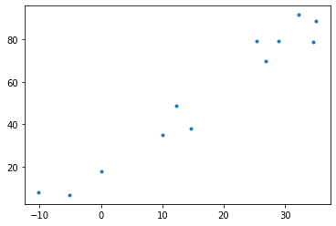

```python
plt.plot(temp,icecream,'.')
```

```python
np.random.seed(2)
eps = np.random.normal(size=12,scale=5)
disease = 30+ temp* 0.5 + eps
```

#### 온도와 소와마비에 관한 산점도

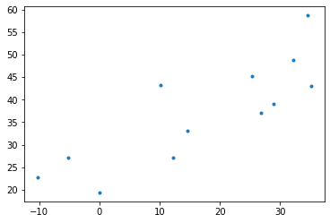

```python
plt.plot(temp, disease,'.' )
```

`-` 원인은 사실 기온에 있었다. 비슷한 기온끼리 묶어놓고 비교를 한다면 사실 아이스크림과 소아마비는 인과관계가 없음이 드러날 것이다.

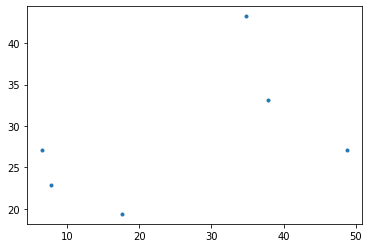

```python
plt.plot(icecream[:6],disease[:6],'.')
```

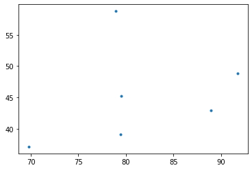

```python
plt.plot(icecream[6:],disease[6:],'.')
```

# 10월 19일 (아이스크림을 많이 먹으면 걸리는 병)

```python
_df=pd.read_csv('https://raw.githubusercontent.com/guebin/DV2022/master/_notebooks/temp.csv')
_df
```

|  | 지점번호 | 지점명 | 일시 | 평균기온(℃) | 최고기온(℃) | 최고기온시각 | 최저기온(℃) |
| --- | --- | --- | --- | --- | --- | --- | --- |
| 0 | 146 | 전주 | 2020-01-01 | -0.5 | 4.3 | 15:09 | -6.4 |
| 1 | 146 | 전주 | 2020-01-02 | 1.4 | 6.5 | 14:12 | -3.0 |
| 2 | 146 | 전주 | 2020-01-03 | 2.6 | 7.6 | 13:32 | -0.5 |
| 3 | 146 | 전주 | 2020-01-04 | 2.0 | 7.7 | 13:51 | -2.6 |
| 4 | 146 | 전주 | 2020-01-05 | 2.5 | 8.6 | 14:05 | -3.2 |
| ... | ... | ... | ... | ... | ... | ... | ... |
| 651 | 146 | 전주 | 2021-10-13 | 19.9 | 25.5 | 14:29 | 15.6 |
| 652 | 146 | 전주 | 2021-10-14 | 20.4 | 25.5 | 13:36 | 17.0 |
| 653 | 146 | 전주 | 2021-10-15 | 18.3 | 22.0 | 13:47 | 15.7 |
| 654 | 146 | 전주 | 2021-10-16 | 12.8 | 17.4 | 0:01 | 6.5 |
| 655 | 146 | 전주 | 2021-10-17 | 6.7 | 12.4 | 15:18 | 2.2 |

656 rows × 7 columns

```python
_df.columns
```

```
Index(['지점번호', '지점명', '일시', '평균기온(℃)', '최고기온(℃)', '최고기온시각', '최저기온(℃)'], dtype='object')
```

```python
temp = np.array(_df.iloc[:,3])
```

### fact 1: 온도 -> 아이스크림 판매량

```python
np.random.seed(1)
eps = np.random.normal(size= len(temp), scale =10)
icecream = 20+ 2*temp + eps
```

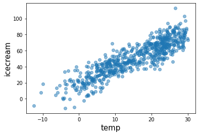

```python
plt.plot(temp, icecream, 'o' , alpha = 0.5)
plt.xlabel("temp", size= 15) # x 라벨
plt.ylabel("icecream", size= 15) #y라벨
```

### fact2 : 온도 -> 소아마비

```python
np.random.seed(2)
eps = np.random.normal(size = len(temp), scale =1 )
disease = 30 + 0.5 * temp + eps
```

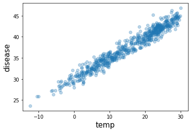

```python
plt.plot(temp,disease,'o', alpha = 0.3)
plt.xlabel("temp", size = 15)
plt.ylabel("disease", size = 15)
```

### 오해: 아이스크림이 소아마비를 유발한다

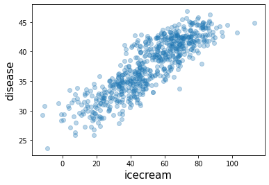

```python
plt.plot(icecream,disease, 'o' , alpha = 0.3)
plt.xlabel("icecream", size = 15)
plt.ylabel("disease", size = 15)
```

#### 상관계수 출력

```python
np.corrcoef(icecream,disease)
```

```
array([[1.        , 0.86298975],
       [0.86298975, 1.        ]])
```

### 온도가 높은 그룹만 살펴보자

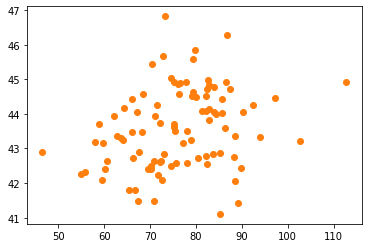

```python
plt.plot(icecream[temp > 25], disease[temp > 25], 'o' , color= 'C1')
```

#### 뇌피셜

별 상관관계가 없어보인다

#### 전체적인 산점도

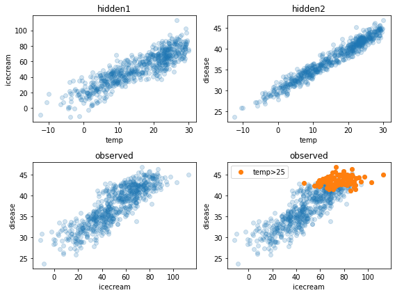

```python
fig , ((ax1,ax2), (ax3,ax4)) = plt.subplots(2,2,figsize=(8,6))
ax1.plot(temp,icecream,'o',alpha=0.2); ax1.set_xlabel('temp'); ax1.set_ylabel('icecream'); ax1.set_title("hidden1")
ax2.plot(temp,disease,'o',alpha=0.2); ax2.set_xlabel('temp'); ax2.set_ylabel('disease'); ax2.set_title("hidden2")
ax3.plot(icecream,disease,'o',alpha=0.2); ax3.set_xlabel('icecream'); ax3.set_ylabel('disease'); ax3.set_title("observed")
ax4.plot(icecream,disease,'o',alpha=0.2); ax4.set_xlabel('icecream'); ax4.set_ylabel('disease'); ax4.set_title("observed")
ax4.plot(icecream[temp>25],disease[temp>25],'o',label='temp>25')
ax4.legend()
fig.tight_layout()
```

## ggplot : 온도 구간을 세분화 하여 시각화

### 목표; 모든 온도 구간에 대해 각각 색을 다르게 할당하여 그려보자

`*` 우리가 봐야하는 변수는 온도, 아이스크림 판매량, 소아마비

`*` 온도가 유사한 지역을 색으로 묶으면 3차원 플랏이 가능함

#### 자료를 데이터 프레임으로 정리해보자

```python
df= pd.DataFrame({'temp':temp, 'icecream':icecream, 'disease':disease})
df
```

|  | temp | icecream | disease |
| --- | --- | --- | --- |
| 0 | -0.5 | 35.243454 | 29.333242 |
| 1 | 1.4 | 16.682436 | 30.643733 |
| 2 | 2.6 | 19.918282 | 29.163804 |
| 3 | 2.0 | 13.270314 | 32.640271 |
| 4 | 2.5 | 33.654076 | 29.456564 |
| ... | ... | ... | ... |
| 651 | 19.9 | 68.839992 | 39.633906 |
| 652 | 20.4 | 76.554679 | 38.920443 |
| 653 | 18.3 | 68.666079 | 39.882650 |
| 654 | 12.8 | 42.771364 | 36.613159 |
| 655 | 6.7 | 30.736731 | 34.902513 |

656 rows × 3 columns

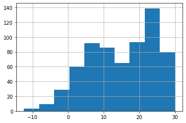

```python
df.temp.hist()
```

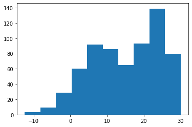

```python
plt.hist(df.temp)
```

## 구간 나누기 방법 1

```python
def cut(x): # 이거보다 더 좋은 방법이 있을 것 같긴 한데요..
    if x<0:
        y='Temp: <0'
    elif x<5:
        y='Temp: 0~5'
    elif x<10:
        y='Temp: 5~10'
    elif x<15:
        y='Temp: 10~15'
    elif x<20:
        y='Temp: 15~20'
    elif x<25:
        y='Temp: 20~25'
    else:
        y='Temp: >30'
    return y
```

```python
df.assign(temp2 = list(map(cut,df.temp)))
```

|  | temp | icecream | disease | temp2 |
| --- | --- | --- | --- | --- |
| 0 | -0.5 | 35.243454 | 29.333242 | Temp: <0 |
| 1 | 1.4 | 16.682436 | 30.643733 | Temp: 0~5 |
| 2 | 2.6 | 19.918282 | 29.163804 | Temp: 0~5 |
| 3 | 2.0 | 13.270314 | 32.640271 | Temp: 0~5 |
| 4 | 2.5 | 33.654076 | 29.456564 | Temp: 0~5 |
| ... | ... | ... | ... | ... |
| 651 | 19.9 | 68.839992 | 39.633906 | Temp: 15~20 |
| 652 | 20.4 | 76.554679 | 38.920443 | Temp: 20~25 |
| 653 | 18.3 | 68.666079 | 39.882650 | Temp: 15~20 |
| 654 | 12.8 | 42.771364 | 36.613159 | Temp: 10~15 |
| 655 | 6.7 | 30.736731 | 34.902513 | Temp: 5~10 |

656 rows × 4 columns

### 시각화 시작

#### 온도를 색으로 구분

```python
fig = ggplot(data = df.assign(temp2 = list(map(cut,df.temp))))
```

```python
p1 = geom_point(aes(x='icecream',y='disease',colour='temp2'),alpha=0.5)
```

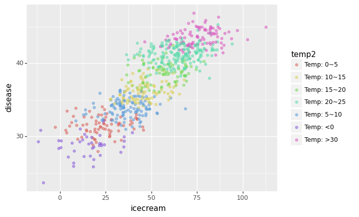

```python
fig + p1
```

#### 추세선 추가

```python
l1 = geom_smooth(aes(x='icecream',y='disease',colour='temp2'))
```

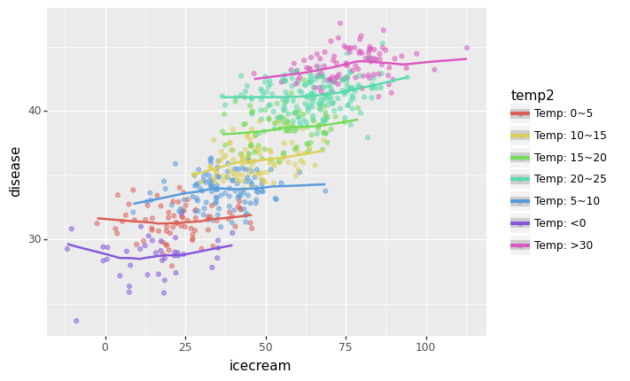

```python
fig + p1 + l1
```

#### 해석

`-` 각 온도별로 추세선은 거의 기울기가 0. -> 온도가 비슷한 구간별로 묶어서 보니까 상관관계가 없다는 것이다.

`-` 아이스크림 판매량과 소아마비의 corr은 유의미해 보였지만, 온도를 통제하였을 경유 아이스크림 판매량과 소아마비의 partial corr는 유의미해 보이지 않았다

`-` 온도와 같은 변수를 은닉변수라고 한다. 뜻은 이름에서 보듯이 은닉된 변수

### 만약 아이스크림이랑 소아마비가 진짜 관련이 있다면?

```python
np.random.seed(1)
eps= np.random.normal(size= len(temp), scale= 10)
icecream = 20 + 2* temp + eps
```

`-` 수영장이 원인이 아니라 진짜 아이스크림을 먹고 소아마비에 걸린 상황이라면

```python
np.random.seed(2)
eps = np.random.normal(size= len(temp),scale =2)
disease = 30 + 0*temp + 0.15* icecream + eps
```

```python
df2 = pd.DataFrame({'temp':temp,'icecream':icecream,'disease':disease})
df2.assign(temp2=list(map(cut,df2.temp)))
```

|  | temp | icecream | disease | temp2 |
| --- | --- | --- | --- | --- |
| 0 | -0.5 | 35.243454 | 34.453002 | Temp: <0 |
| 1 | 1.4 | 16.682436 | 32.389832 | Temp: 0~5 |
| 2 | 2.6 | 19.918282 | 28.715350 | Temp: 0~5 |
| 3 | 2.0 | 13.270314 | 35.271089 | Temp: 0~5 |
| 4 | 2.5 | 33.654076 | 31.461240 | Temp: 0~5 |
| ... | ... | ... | ... | ... |
| 651 | 19.9 | 68.839992 | 39.693811 | Temp: 15~20 |
| 652 | 20.4 | 76.554679 | 38.924088 | Temp: 20~25 |
| 653 | 18.3 | 68.666079 | 41.765212 | Temp: 15~20 |
| 654 | 12.8 | 42.771364 | 36.842022 | Temp: 10~15 |
| 655 | 6.7 | 30.736731 | 37.715537 | Temp: 5~10 |

656 rows × 4 columns

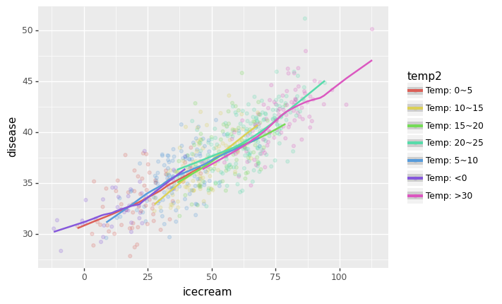

```python
ggplot(data= df2.assign(temp2= list(map(cut,df2.temp)))) +\
geom_point(aes(x='icecream',y='disease',colour='temp2'),alpha=0.2) +\
geom_smooth(aes(x='icecream',y='disease',colour='temp2'))
```

partial corr도 유의미하게 나와버린 모습이다..

```python
df.corr()
```

|  | temp | icecream | disease |
| --- | --- | --- | --- |
| temp | 1.000000 | 0.884366 | 0.975609 |
| icecream | 0.884366 | 1.000000 | 0.862990 |
| disease | 0.975609 | 0.862990 | 1.000000 |

```python
df2.corr()
```

|  | temp | icecream | disease |
| --- | --- | --- | --- |
| temp | 1.000000 | 0.884366 | 0.725505 |
| icecream | 0.884366 | 1.000000 | 0.830539 |
| disease | 0.725505 | 0.830539 | 1.000000 |